# Analyzing the Relationship between Air Pollutants and Carbon Dioxide Emissions in Singapore

### Distribution of Each Air Pollutant and Number of Respiratory Infection Cases (Histogram)

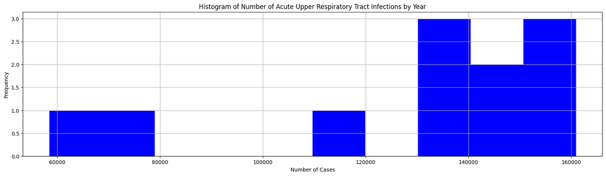

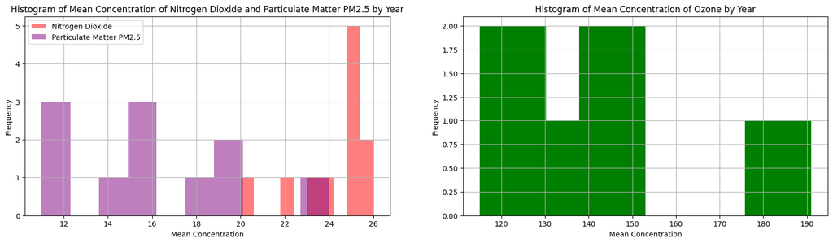

```python
# histogram to look at the distribution of the datasets

# plot respiratory
plt.figure(figsize=(20, 5))
plt.hist(respiratory_cases_by_year, bins=10, color="blue")
plt.title("Histogram of Number of Acute Upper Respiratory Tract Infections by Year")
plt.xlabel("Number of Cases")
plt.ylabel("Frequency")
plt.grid()
plt.show()


# plot no2 and pm2.5 together (left) and ozone (right)
plt.figure(figsize=(20, 5))

# plot no2 and pm2.5 together (left)
plt.subplot(1, 2, 1)
plt.hist(no2_data[:, 1], bins=10, color="red", alpha=0.5, label="Nitrogen Dioxide") # set alpha due to possible overlap of data
plt.hist(pm25_data[:, 1], bins=10, color="purple", alpha=0.5, label="Particulate Matter PM2.5") # set alpha due to possible overlap of data
plt.title("Histogram of Mean Concentration of Nitrogen Dioxide and Particulate Matter PM2.5 by Year")
plt.xlabel("Mean Concentration")
plt.ylabel("Frequency")
plt.legend()
plt.grid()

# plot ozone (right)
plt.subplot(1, 2, 2)
plt.hist(ozone_data[:, 1], bins=10, color="green")
plt.title("Histogram of Mean Concentration of Ozone by Year")
plt.xlabel("Mean Concentration")
plt.ylabel("Frequency")
plt.grid()

plt.show()
```

#### Analysis of Histogram

Question:  
What is the distribution of NO2, Ozone and PM2.5 levels?

Answer:  
The histogram shows that NO2 levels are most frequently between 25 and 26 units while PM2.5 has a wider and more equal spread across 11 to 20 units. NO2 levels are the most concentrated  
with less variability, while PM2.5 levels are more evenly spread out with moderate variability. While for Ozone, the levels are mostly between about 115 units to about 152 units. Which is significally higher than the other air pollutions. This data indicates different behavior and pollution levels for each pollutant, with NO2 being more localized, PM2.5 more evenly distributed, and Ozone haivng a higher and more specific concentration range.

### Correlation between pollutants and Number of Respiratory Infection Cases (Scatter Plot)

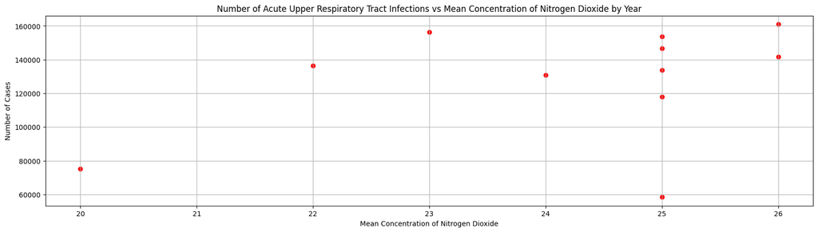

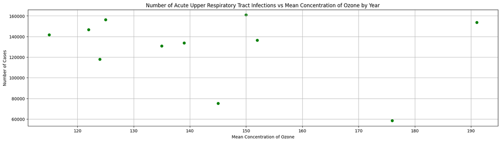

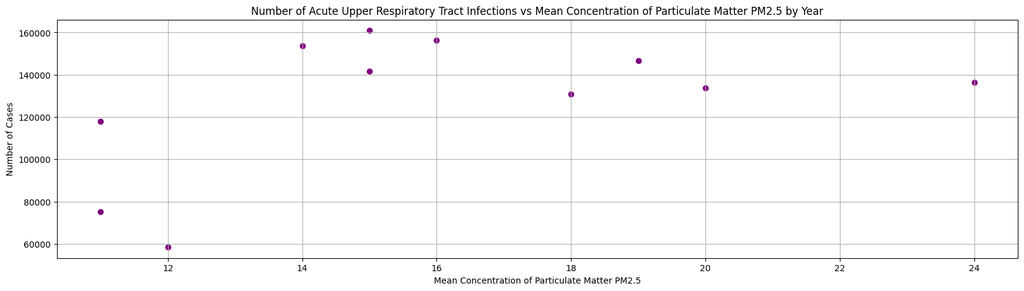

```python
# scatter plot to look for possible correlation between datasets
# will plot 6 different graphs with every 2 graphs comapring number of cases to 1 air pollutant.
# for each air pollutant, will plot number of cases vs air pollutant concentration
# 2 graphs for each air pollutant, 1 for highest mean concentration 1 for lowest mean concentration


# function for plotting scatter
def scatter_plot(x_axis:np.ndarray, y_axis:np.ndarray, title:str, x_label:str, y_label:str, color:str):
  '''
  This function takes in 2 numpy arrays and plots a scatter plot of the data.

  Args:
    x_axis: numpy array of x-axis data
    y_axis: numpy array of y-axis data
    title: title of the scatter plot
    x_label: x-axis label
    y_label: y-axis label
    color: color of the scatter plot
  '''
  plt.figure(figsize=(20, 5))
  plt.scatter(x_axis, y_axis, color=color)
  plt.title(title)
  plt.xlabel(x_label)
  plt.ylabel(y_label)
  plt.grid()
  plt.show()


# # plot num of cases vs NO2
scatter_plot(
  no2_data[:, 1], respiratory_cases_by_year,
  "Number of Acute Upper Respiratory Tract Infections vs Mean Concentration of Nitrogen Dioxide by Year",
  "Mean Concentration of Nitrogen Dioxide", "Number of Cases", "red"
)


# # plot num of cases vs Ozone
scatter_plot(
  ozone_data[:, 1], respiratory_cases_by_year,
  "Number of Acute Upper Respiratory Tract Infections vs Mean Concentration of Ozone by Year",
  "Mean Concentration of Ozone", "Number of Cases", "green"
)


# # plot num of cases vs PM2.5
scatter_plot(
  pm25_data[:, 1], respiratory_cases_by_year,
  "Number of Acute Upper Respiratory Tract Infections vs Mean Concentration of Particulate Matter PM2.5 by Year",
  "Mean Concentration of Particulate Matter PM2.5", "Number of Cases", "purple"
)
```

#### Analysis of Scatter Plot

Question:  
Which air pollutant appears to have the strongest correlation to the number of respiratory infections cases?

Answer:  
Based on our analysis, the air pollutant that appears to have the strongest correlation to the number of respiratory infections cases is Nitrogen Dioxide (NO2) as it has some small correlation to the number of respiratory infections cases as analyzed before. On the other hand, the other 2 air pollutants has no correlation to the number of respiratory infections cases.

### Comparison of Air Pollutants Concentration Against Number of Respiratory Infections Cases by Year (Bar Graph)

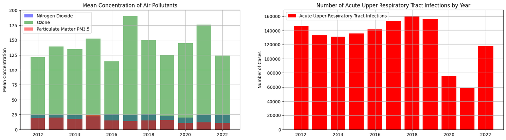

```python
# bar graph to compare concentration of air pollutants and number of cases of respiratory diseases
# 2 graphs side by side
# 1 graph contains all air pollutants
# 1 graph contains the number of cases of respiratory diseases

plt.figure(figsize=(20, 5))

# plot air pollutants (left)
plt.subplot(1, 2, 1)
plt.bar(no2_data[:, 0], no2_data[:, 1], color="blue", label="Nitrogen Dioxide", alpha=0.5)
plt.bar(ozone_data[:, 0], ozone_data[:, 1], color="green", label="Ozone", alpha=0.5)
plt.bar(pm25_data[:, 0], pm25_data[:, 1], color="red", label="Particulate Matter PM2.5", alpha=0.5)
plt.title("Mean Concentration of Air Pollutants")
plt.ylabel("Mean Concentration")
plt.legend()
plt.grid()


# # plot respiratory (right)
plt.subplot(1, 2, 2)
plt.bar(respiratory_unique_years, respiratory_cases_by_year, color="red", label="Acute Upper Respiratory Tract Infections")
plt.title("Number of Acute Upper Respiratory Tract Infections by Year")
plt.ylabel("Number of Cases")
plt.legend()
plt.grid()


plt.show()
```

#### Analysis of Bar Graph

Question:  
How did the mean concentration of air pollutants change over the course of 2012 to 2022?

Answer:  
The mean concentration of air pollution has flucutated over the years. Nitrogen Dioxide (NO2) and PM2.5 show some slight variation but remain relatively stable. PM2.5 however, has a sudden spike in concentration during 2015 which allowed PM2.5 to have a higher mean concentration than NO2 which is the only anomaly when comparing PM2.5 to Nitrogen, as throughout the years, aside from 2015, PM2.5 has always been lower than NO2.

### Analyzing proportion of the different data sets (Pie Chart)

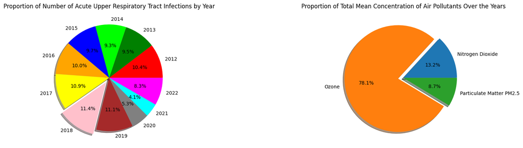

```python
# pie chart to analyze the proportion of datasets
# 2 pie charts side by side
# 1 pie chart contains the proportion of respiratory diseases based on year
# 1 pie chart contains the proportion of air pollutants over every year
plt.figure(figsize=(20, 5))
cases_colors = ["red", "green", "lime", "blue", "orange", "yellow", "pink", "brown", "gray", "cyan", "magenta"]


# 1 pie chart contains the proportion of respiratory diseases based on year
max_cases = np.max(respiratory_cases_by_year)
pollutant_explode = [0.1 if i == max_cases else 0 for i in respiratory_cases_by_year]

plt.subplot(1, 2, 1)
plt.pie(respiratory_cases_by_year, labels=respiratory_unique_years, autopct="%1.1f%%", colors=cases_colors, explode=pollutant_explode, shadow=True)
plt.title("Proportion of Number of Acute Upper Respiratory Tract Infections by Year")

# 1 pie chart contains the proportion of air pollutants
pollutant_sum = {
  "no2_sum": np.sum(no2_data[:, 1]),
  "ozone_sum": np.sum(ozone_data[:, 1]),
  "pm25_sum": np.sum(pm25_data[:, 1])
}
cases_explode = [0.1 if i == np.max(list(pollutant_sum.values())) else 0 for i in list(pollutant_sum.values())]

plt.subplot(1, 2, 2)
plt.pie([pollutant_sum["no2_sum"], pollutant_sum["ozone_sum"], pollutant_sum["pm25_sum"]], labels=["Nitrogen Dioxide", "Ozone", "Particulate Matter PM2.5"], autopct="%1.1f%%", explode=cases_explode, shadow=True)
plt.title("Proportion of Total Mean Concentration of Air Pollutants Over the Years")


plt.show()
```

#### Analysis of Pie Chart

Question:  
In which year are the number of respiratory infections cases the most?

Answer:  
Based on the Pie chart, 2018 has the highest number of respiratory infections cases. However it is not by large margin. Based on the Pie chart, it can be seen that most of the quadrants are similar in size, with the exception of 2 or 3 quadrants. This shows that even though 2018 has the highest number of cases, generally the number of cases are about that high, with the exception of a few years.

Question:  
Which air pollutant is the most abundant in this pie chart?

Answer:  
Based on the Pie chart, Ozone is the most abundant in the atmosphere by a large margin. Followed by Nitrogen Dioxide (NO2) then Particulate Matter PM2.5, though the difference between the 2 is not much. The high concentration of ozone is likely due to factors such as Photochemical reactions, which is a reaction involving nitrogen oxides and volatile organic compounds in the presence of sunlight. Next, the NO2 is the second most abundant air pollutant as is primarily released due to combustion processes such as vehicle engines, power plants, and industrial activities. Lastly, PM2.5 which even though is the least abundant, it still poses health risks, is released during combustion processes, similar to NO2.